# Lab 1a. Species Distribution Modeling - Exploratory Data Analysis

Juliet

1/6/2022

## Lab 1a. Species Distribution Modeling - Exploratory Data Analysis

### Learning Objectives

#### Explore

- Fetch species observations from the Global Biodiversity Information Facility (GBIF.org) using an R package that wraps a function around their API.
- Fetch environmental data for defining environmental relationship in the species distribution model (SDM).
- Generate pseudo-absences, or background, points with which to differentiate from the species presence points in the SDM.
- Extract underlying environmental data from points.
- Plot term plots of each environmental predictor with the species response.

### 1 Overview

This lab will introduce you to machine learning by predicting presence of a species of you choosing from observations and environmental data. We will largely follow guidance found at Species distribution modeling | R Spatial using slightly newer R packages and functions.

### 2 Explore

This first part of the lab involves fetching data for your species of interest, whether terrestrial or marine.

### Section 2.1 Install Packages

```r
# load packages, installing if missing
if (!require(librarian)){
  install.packages("librarian")
  library(librarian)
}
```

```r
librarian::shelf(
  dismo, dplyr, DT, ggplot2, here, htmltools, leaflet, mapview, purrr, raster, readr, rgbif, rgdal, rJava, sdmpredictors, sf, spocc, tidyr)
```

```
##
##   The 'cran_repo' argument in shelf() was not set, so it will use
##   cran_repo = 'https://cran.r-project.org' by default.
##
##   To avoid this message, set the 'cran_repo' argument to a CRAN
##   mirror URL (see https://cran.r-project.org/mirrors.html) or set
##   'quiet = TRUE'.
```

```r
select <- dplyr::select # overwrite raster::select
options(readr.show_col_types = FALSE)

# set random seed for reproducibility
set.seed(42)

# directory to store data
dir_data <- here("ferret_data/sdm")
dir.create(dir_data, showWarnings = F, recursive = TRUE)
```

### Section 2.2 Choose a Species

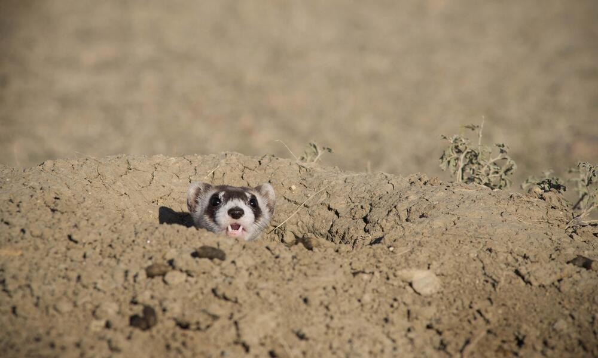

The black-footed ferret, *Mustela nigripes*

For my species distribution model, I will analyze the black-footed ferret, *Mustela nigripes*, which is an endangered mammal species that typically inhabits grasslands in the Northern Great Plains of the U.S. Black-footed ferrets are one of the most endangered mammals in North America and are the only ferret species native to the continent. The main sources of their population decline include habitat loss and disease. Therefore, it is exceptionally important that we protect understand their preferred habitat and environmental characteristics and protect the regions that fit that criteria. (source: [World Wildlife](https://www.worldwildlife.org/species/black-footed-ferret))

### Section 2.3 Get Species Observations

```r
obs_csv <- file.path(dir_data, "obs.csv")
obs_geo <- file.path(dir_data, "obs.geojson")
redo    <- FALSE

if (!file.exists(obs_geo) | redo){
  # get species occurrence data from GBIF with coordinates
  (res <- spocc::occ(
    query = 'Mustela nigripes',
    from = 'gbif', has_coords = T,
    limit = 10000))

  # extract data frame from result
  df <- res$gbif$data[[1]]
  readr::write_csv(df, obs_csv)

  # convert to points of observation from lon/lat columns in data frame
  obs <- df %>%
    sf::st_as_sf(
      coords = c("longitude", "latitude"),
      crs = st_crs(4326)) %>%
    select(prov, key) # save space (joinable from obs_csv)
  sf::write_sf(obs, obs_geo, delete_dsn=T)
}
obs <- sf::read_sf(obs_geo)
nrow(obs) # number of rows
```

```
## [1] 202
```

**Question 1. How many observations total are in GBIF for your species?**

There are 202 observations for the black-footed ferret because there are 202 rows. This may be slightly over-exaggerating the number of observations if there are duplicate observations or the observations are null for a different reason, such as incorrect coordinates or imprecise coordinates.

### Map the initial species observations

```r
# show points on map
mapview::mapview(obs, map.types = "Esri.NatGeoWorldMap")
```

[interactive chart not shown]

**Question 2. Do you see any odd observations, like marine species on land or vice versa? If so, please see the Data Cleaning and explain what you did to fix or remove these points.**

I do not see any odd observations such as terrestrial black-footed ferret points documented in aquatic habitat. However, taking a look at the `geometry` column in for the `obs` dataframe, I noticed that there are duplicate points as well as points with very few decimal points for the latitude and/or longitude, meaning that these points are not accurate enough to reliably provide insight into the type of habitat that the black-footed ferret prefers. Therefore, I will remove observations (based on the geometry column) that are duplicates of the same individual, and remove observations that have fewer than 3 decimal places of precision in the geometry column. I chose to remove observations that only have 2 or 1 decimal places of precision in either the latitude or longitude values because 3 decimal places is accurate to ~110 meters at the equator, but 2 decimal degrees is only accurate to only ~1,100 meters at the equator. Therefore, 3 decimal places is much more likely to yield accurate correlations between where the individual was recorded and the altitude, temperature, and other environmental variables of interest at that location ([source](https://gis.stackexchange.com/questions/8650/measuring-accuracy-of-latitude-and-longitude)). This leaves 149 observations in my dataframe.

```r
# find duplicate coordinates, this function creates a vector of T or F for each of the 202 points
duplicates <- duplicated(obs$geometry)

# how many duplicates were there? This will sum only the TRUE values
sum(duplicates)
```

```
## [1] 46
```

```r
# add duplicates as a col to the obs dataframe to see which rows were duplicates
obs_check_dup <- obs %>%
  mutate(dups = duplicates)

# seems like the duplicates function gives TRUE for all rows that match other rows, not just the second copy of the row, so we need to keep 1 copy and remove only the second copy by setting .keep_all = T
obs_no_dup_check <- obs_check_dup %>%
  distinct(geometry, .keep_all = TRUE)

# remove observations that have fewer than 3 decimal places for either the latitude or longitude
obs_clean <- obs_no_dup_check[-c(108, 124, 133, 137, 144, 146, 148), ] %>%
  select(prov, key, geometry)
```

### Section 2.4 Get Environmental Data

Use the Species Distribution Model predictors R package `sdmpredictors` to get underlying environmental data for your observations. First you’ll get underlying environmental data for predicting the niche on the species observations. Then you’ll generate pseudo-absence points with which to sample the environment. The model will differentiate the environment of the presence points from the pseudo-absence points.

#### 2.4.1 Presence

```r
dir_env <- file.path(dir_data, "env")

# set a default data directory
options(sdmpredictors_datadir = dir_env)

# choosing terrestrial
env_datasets <- sdmpredictors::list_datasets(terrestrial = TRUE, marine = FALSE)

# show table of datasets
env_datasets %>%
  select(dataset_code, description, citation) %>%
  DT::datatable()
```

|  | dataset_code | description | citation |
| --- | --- | --- | --- |
| 1 | WorldClim | WorldClim is a set of global climate layers (climate grids). Note that all data has been transformed back to real values, so there is no need to e.g. divide temperature layers by 10. | Hijmans, R.J., S.E. Cameron, J.L. Parra, P.G. Jones and A. Jarvis, 2005. Very high resolution interpolated climate surfaces for global land areas. International Journal of Climatology 25: 1965-1978. |
| 4 | ENVIREM | The ENVIREM dataset is a set of 16 climatic and 2 topographic variables that can be used in modeling species' distributions. The strengths of this dataset include their close ties to ecological proces… | Title, P.O., Bemmels, J.B. 2017. ENVIREM: An expanded set of bioclimatic and topographic variables increases flexibility and improves performance of ecological niche modeling. Ecography doi: 10.1111/e… |
| 5 | Freshwater | The dataset consists of near-global, spatially continuous, and freshwater-specific environmental variables in a standardized 1km grid. We delineated the sub-catchment for each grid cell along the Hydr… | Domisch, S., Amatulli, G., and Jetz, W. (2015) Near-global freshwater-specific environmental variables for biodiversity analyses in 1 km resolution. Scientific Data 2:150073 doi: 10.1038/sdata.2015.73 |

```r
# choose datasets for a vector
env_datasets_vec <- c("WorldClim", "ENVIREM")

# get layers
env_layers <- sdmpredictors::list_layers(env_datasets_vec)
DT::datatable(env_layers)
```

|  | dataset_code | layer_code | name | description | terrestrial | marine | freshwater | cellsize_equalarea | cellsize_lonlat | units | primary_type | primary_spatial_resolution | primary_source | start_year | start_month | start_day | end_year | end_month | end_day | derivation | month | is_surface | version | layer_url |
| --- | --- | --- | --- | --- | --- | --- | --- | --- | --- | --- | --- | --- | --- | --- | --- | --- | --- | --- | --- | --- | --- | --- | --- | --- |
| 1 | WorldClim | WC_alt | Altitude | Altitude | True | False | False | 7000 | 0.083333333 | meters | Satellite (SRTM), GTOPO30 | 3 arcsecond, 30 arsecond | SRTM: CGIAR-CSI, reference: Jarvis, A., H.I. Reuter, A. Nelson, E. Guevara, 2008, Hole-filled SRTM for the globe Version 4, available from the CGIAR-CSI SRTM 90m Database (http://srtm.csi.cgiar.org). … | 1950 | 1 | 1 | 2000 | 1 | 1 | '' |  | True | 1 | https://www.lifewatch.be/sdmpredictors/WC_alt_lonlat.tif |
| 2 | WorldClim | WC_bio1 | Annual mean temperature | Annual mean temperature | True | False | False | 7000 | 0.083333333 | Celsius | in situ measurement | '' | Weather station data from multiple sources, see Hijmans, R.J., S.E. Cameron, J.L. Parra, P.G. Jones and A. Jarvis, 2005. Very high resolution interpolated climate surfaces for global land areas. Inter… | 1950 | 1 | 1 | 2000 | 1 | 1 | mean, thin-plate smoothing splines |  | True | 1 | https://www.lifewatch.be/sdmpredictors/WC_bio1_lonlat.tif |
| 3 | WorldClim | WC_bio2 | Mean diurnal temperature range | Mean of the monthly (maximum temperature - minimum temperature) | True | False | False | 7000 | 0.083333333 | Celsius | in situ measurement | '' | Weather station data from multiple sources, see Hijmans, R.J., S.E. Cameron, J.L. Parra, P.G. Jones and A. Jarvis, 2005. Very high resolution interpolated climate surfaces for global land areas. Inter… | 1950 | 1 | 1 | 2000 | 1 | 1 | mean range, thin-plate smoothing splines |  | True | 1 | https://www.lifewatch.be/sdmpredictors/WC_bio2_lonlat.tif |
| 4 | WorldClim | WC_bio3 | Isothermality | Mean diurnal temperature range (bio2) / Annual temperature range (bio7) | True | False | False | 7000 | 0.083333333 | Celsius | in situ measurement | '' | Weather station data from multiple sources, see Hijmans, R.J., S.E. Cameron, J.L. Parra, P.G. Jones and A. Jarvis, 2005. Very high resolution interpolated climate surfaces for global land areas. Inter… | 1950 | 1 | 1 | 2000 | 1 | 1 | '' |  | True | 1 | https://www.lifewatch.be/sdmpredictors/WC_bio3_lonlat.tif |
| 5 | WorldClim | WC_bio4 | Temperature seasonality | Standard deviation of the annual mean temperature | True | False | False | 7000 | 0.083333333 | Celsius | in situ measurement | '' | Weather station data from multiple sources, see Hijmans, R.J., S.E. Cameron, J.L. Parra, P.G. Jones and A. Jarvis, 2005. Very high resolution interpolated climate surfaces for global land areas. Inter… | 1950 | 1 | 1 | 2000 | 1 | 1 | standard deviation, thin-plate smoothing splines |  | True | 1 | https://www.lifewatch.be/sdmpredictors/WC_bio4_lonlat.tif |
| 6 | WorldClim | WC_bio5 | Maximum temperature | Maximum temperature of the warmest month | True | False | False | 7000 | 0.083333333 | Celsius | in situ measurement | '' | Weather station data from multiple sources, see Hijmans, R.J., S.E. Cameron, J.L. Parra, P.G. Jones and A. Jarvis, 2005. Very high resolution interpolated climate surfaces for global land areas. Inter… | 1950 | 1 | 1 | 2000 | 1 | 1 | maximum, thin-plate smoothing splines |  | True | 1 | https://www.lifewatch.be/sdmpredictors/WC_bio5_lonlat.tif |
| 7 | WorldClim | WC_bio6 | Minimum temperature | Minimum temperature of the coldest month | True | False | False | 7000 | 0.083333333 | Celsius | in situ measurement | '' | Weather station data from multiple sources, see Hijmans, R.J., S.E. Cameron, J.L. Parra, P.G. Jones and A. Jarvis, 2005. Very high resolution interpolated climate surfaces for global land areas. Inter… | 1950 | 1 | 1 | 2000 | 1 | 1 | minimum, thin-plate smoothing splines |  | True | 1 | https://www.lifewatch.be/sdmpredictors/WC_bio6_lonlat.tif |
| 8 | WorldClim | WC_bio7 | Annual temperature range | Maximum temperature (bio5) - minimum temperature (bio6) | True | False | False | 7000 | 0.083333333 | Celsius | in situ measurement | '' | Weather station data from multiple sources, see Hijmans, R.J., S.E. Cameron, J.L. Parra, P.G. Jones and A. Jarvis, 2005. Very high resolution interpolated climate surfaces for global land areas. Inter… | 1950 | 1 | 1 | 2000 | 1 | 1 | range, thin-plate smoothing splines |  | True | 1 | https://www.lifewatch.be/sdmpredictors/WC_bio7_lonlat.tif |
| 9 | WorldClim | WC_bio8 | Mean temperature of wettest quarter | Mean temperature of wettest quarter | True | False | False | 7000 | 0.083333333 | Celsius | in situ measurement | '' | Weather station data from multiple sources, see Hijmans, R.J., S.E. Cameron, J.L. Parra, P.G. Jones and A. Jarvis, 2005. Very high resolution interpolated climate surfaces for global land areas. Inter… | 1950 | 1 | 1 | 2000 | 1 | 1 | mean, thin-plate smoothing splines |  | True | 1 | https://www.lifewatch.be/sdmpredictors/WC_bio8_lonlat.tif |
| 10 | WorldClim | WC_bio9 | Mean temperature of driest quarter | Mean temperature of driest quarter | True | False | False | 7000 | 0.083333333 | Celsius | in situ measurement | '' | Weather station data from multiple sources, see Hijmans, R.J., S.E. Cameron, J.L. Parra, P.G. Jones and A. Jarvis, 2005. Very high resolution interpolated climate surfaces for global land areas. Inter… | 1950 | 1 | 1 | 2000 | 1 | 1 | mean, thin-plate smoothing splines |  | True | 1 | https://www.lifewatch.be/sdmpredictors/WC_bio9_lonlat.tif |

[output cut: 76 more lines]